# PCAngsd_angsd1

Julia Harenčár

2/25/2021

This markdown summarizes the PCAs I generated by running PCAngsd on the genotype likelihood (beagle) file output of angsd run 1, which uses samtools as the variant caller (see AVHonly_ANGSD1_beagles.slurm in angsd_runs/).

#### PCAs of alle, vill, and hybrids only

PCAngsd run with estimation of independent allele frequencies. Plot created from output of the following code:  
`pcangsd.py -beagle $IN_DIR/AVH_only.genolike.beagle.gz -o $OUT_DIR/AVH_only_PCAngsd_IAF`

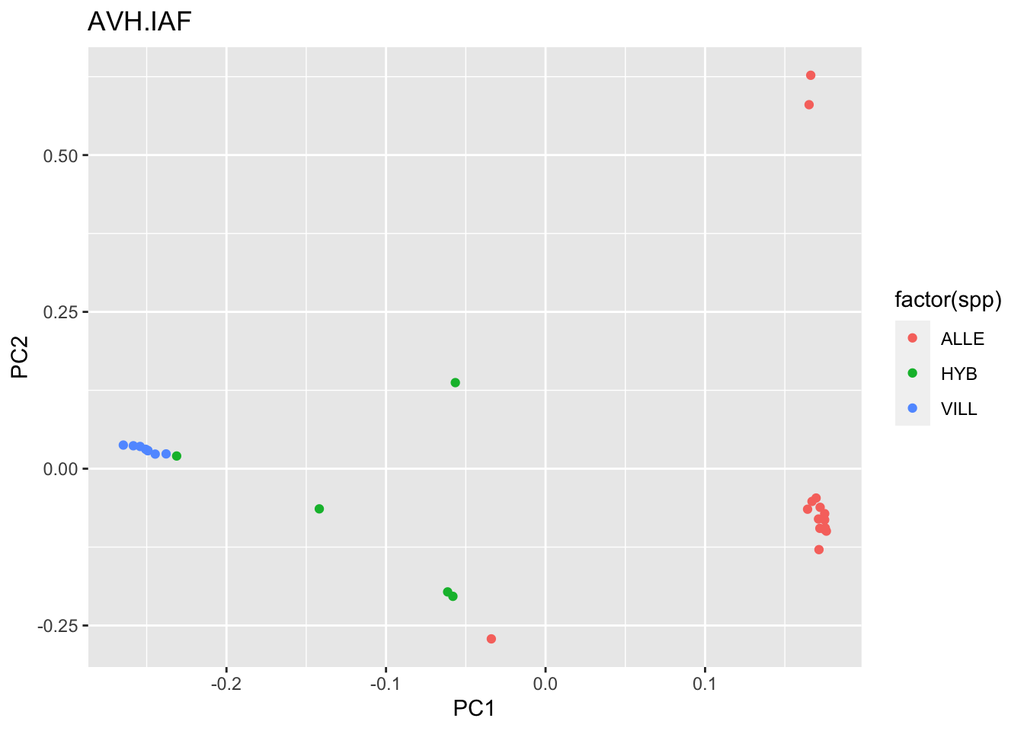

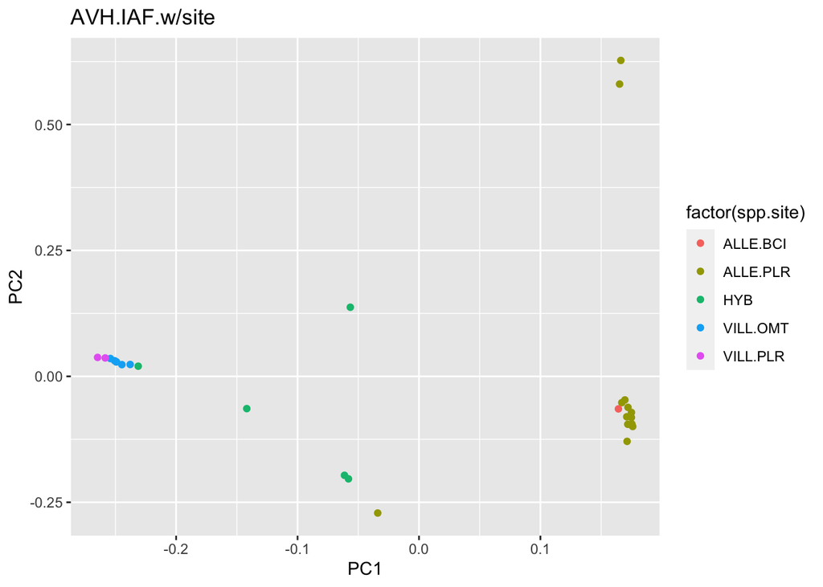

PCAngsd run without estimation of independent allele frequencies. Plot created from output of the following code:  
`pcangsd.py -beagle $IN_DIR/AVH_only.genolike.beagle.gz -o $OUT_DIR/AVH_only_PCAngsd -iter 0`

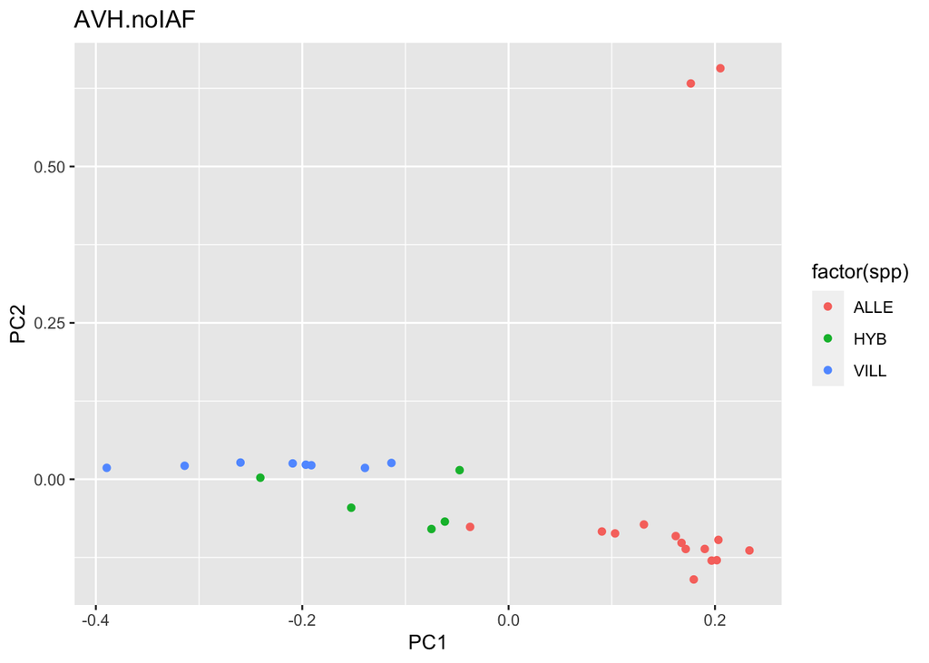

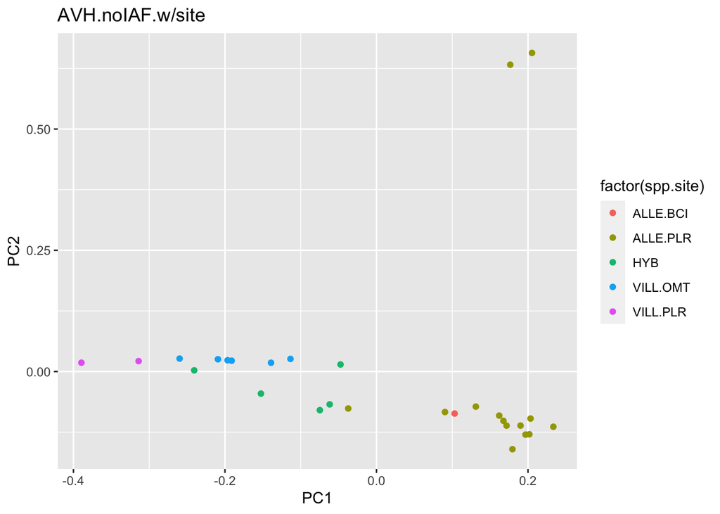

#### PCAs of laev, guan, alle, vill, and alle x vill hybrids.

PCAngsd run with estimation of independent allele frequencies. Plot created from output of the following code:  
`pcangsd.py -beagle $IN_DIR/L.G.A.V.H.genolike.beagle.gz -o $OUT_DIR/L.G.A.V.H_PCAngsd_IAF`

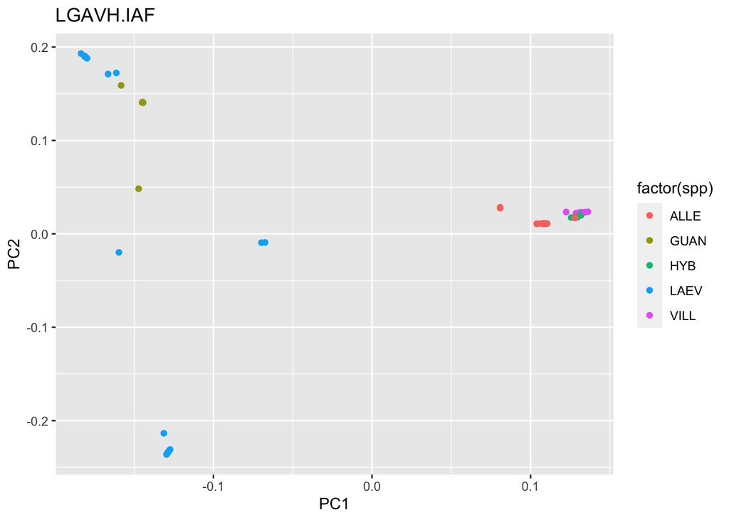

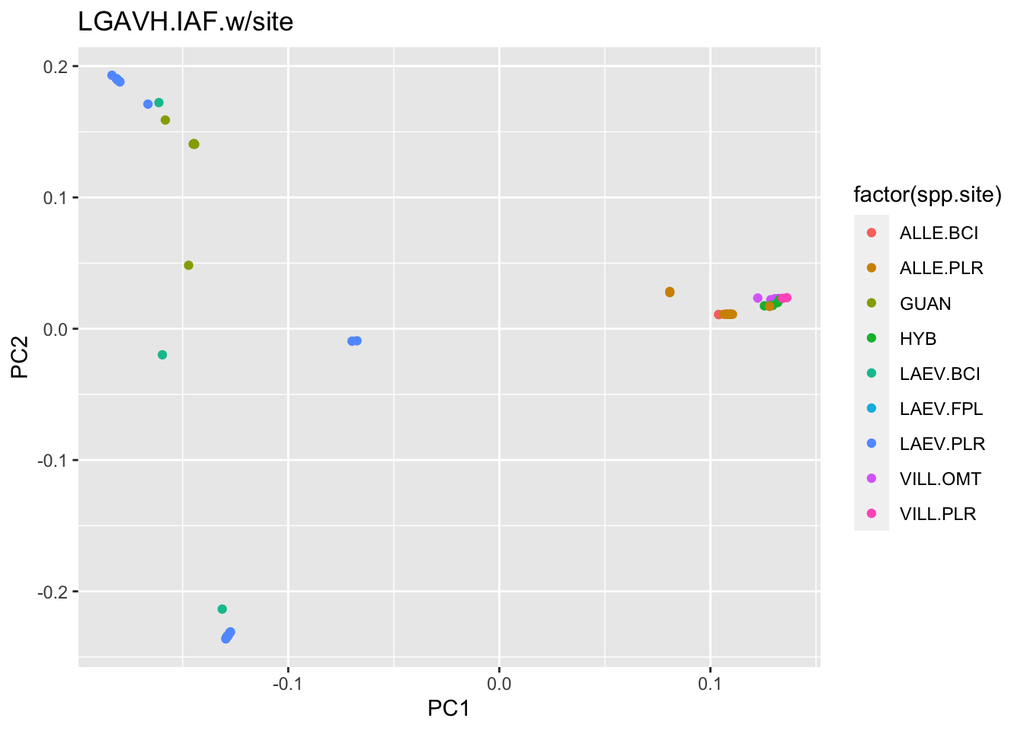

PCAngsd run without estimation of independent allele frequencies. Plot created from output of the following code:  
`pcangsd.py -beagle $IN_DIR/L.G.A.V.H.genolike.beagle.gz -o $OUT_DIR/L.G.A.V.H_PCAngsd -iter 0`

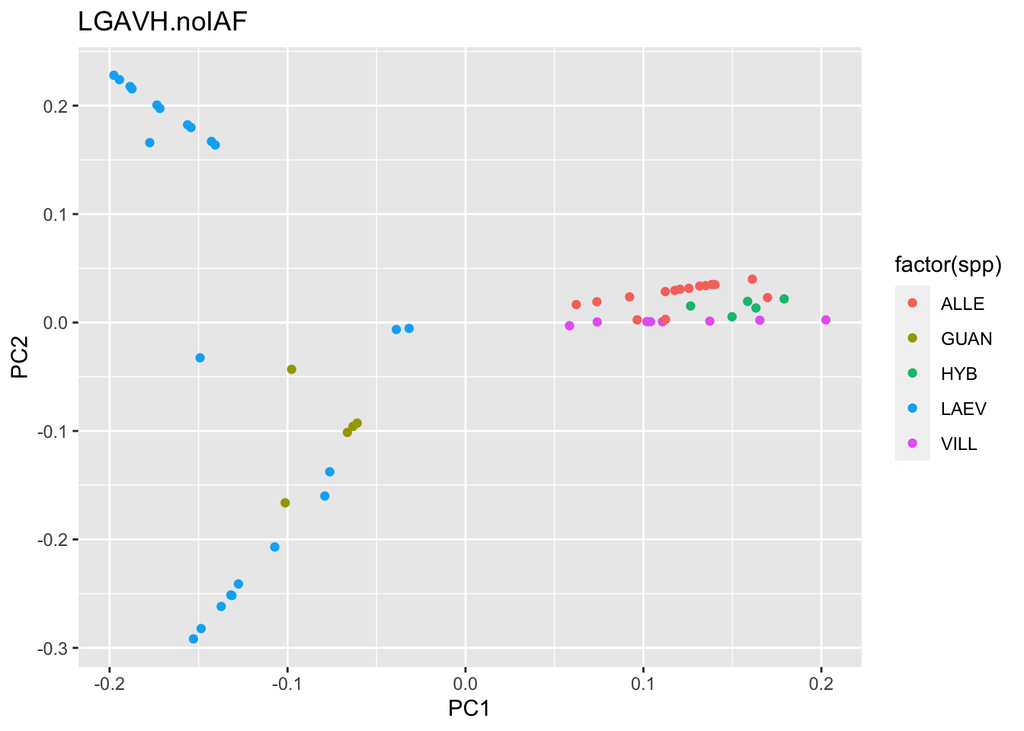

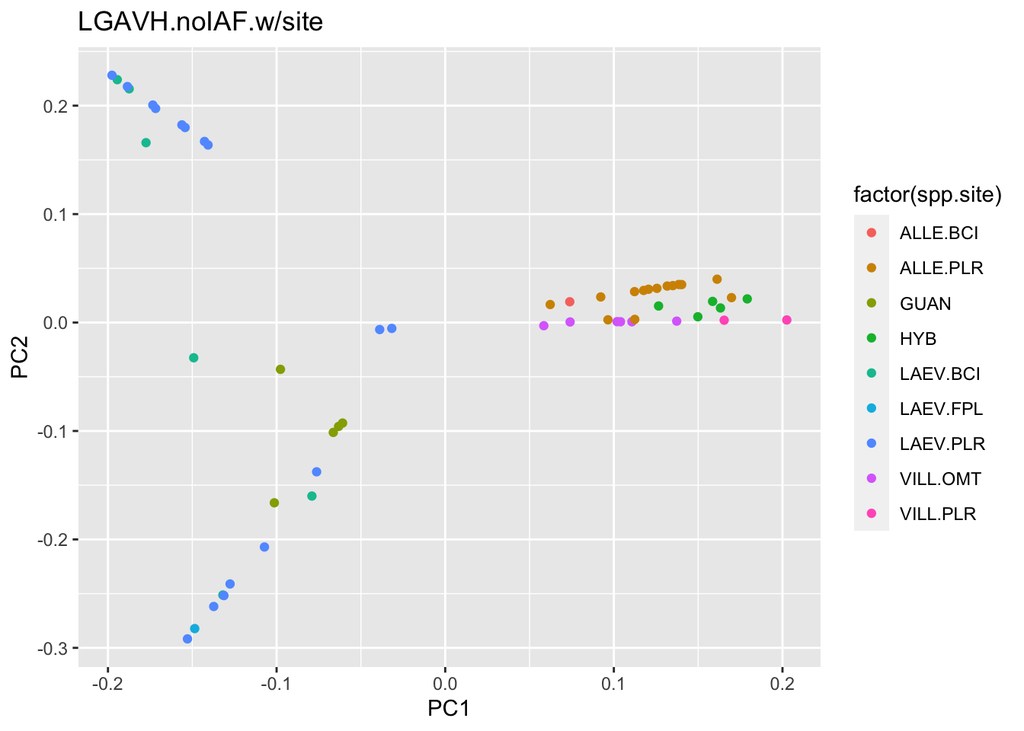